# CLASSICAL INFERENCE: CONFIDENCE INTERVALS

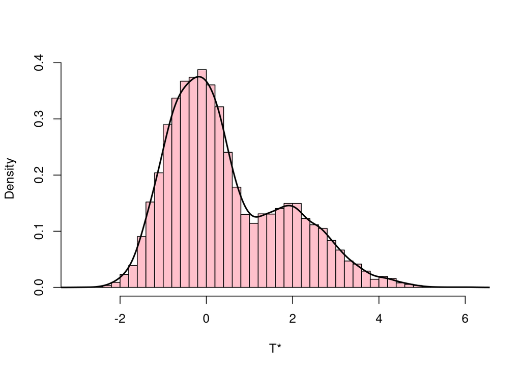

```r
hist((boot.out$t[,1] - boot.out$t0[1])/(boot.out$t[,2])^.5, col = "pink", breaks = "Scott", main = "", xlab ="T*", freq= FALSE)
lines(density((boot.out$t[,1] - boot.out$t0[1])/(boot.out$t[,2])^.5), lwd = 2)
```

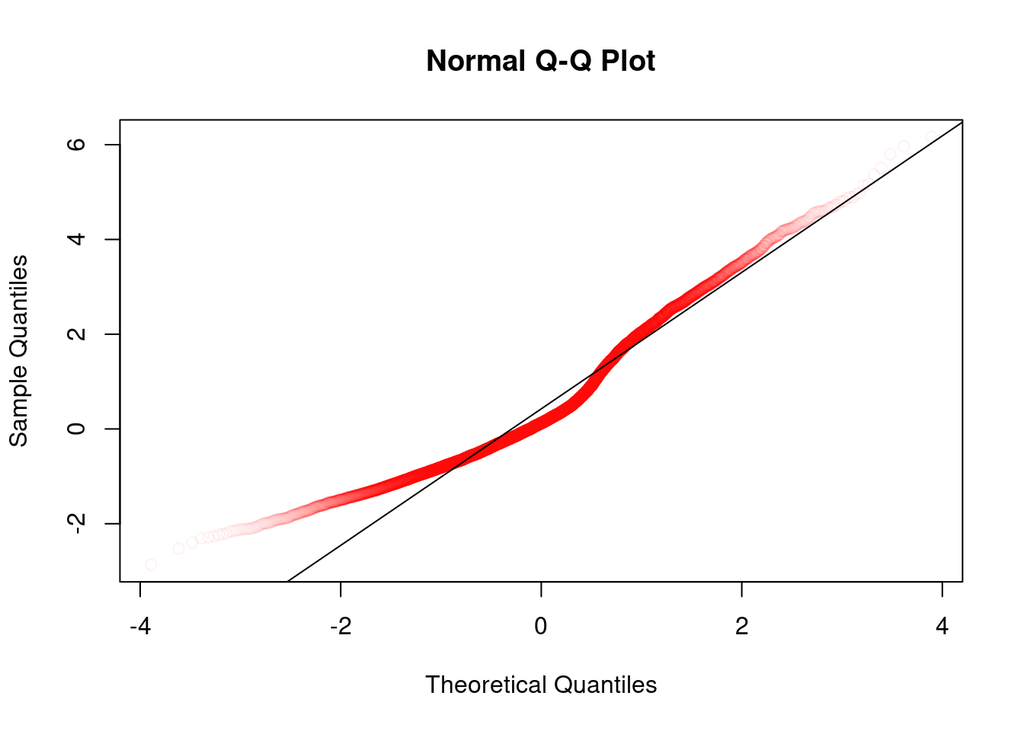

```r
qqnorm((boot.out$t[,1] - boot.out$t0[1])/(boot.out$t[,2])^.5, col = rgb(1,0,0,.05))
qqline((boot.out$t[,1] - boot.out$t0[1])/(boot.out$t[,2])^.5)
```

**7.5.1 Comparing Bootstrap $t$ and Formula $t$ Confidence Intervals**

It is useful to compare the bootstrap distribution to classical statistical inferences. With classical $t$ intervals of the form $\bar{x} \pm t \times s/\sqrt{n},$ the confidence interval width varies substantially in small samples as the sample standard deviation $s$ varies. Correspondingly, the classical standard error $s/\sqrt{n}$ varies as $s$ varies. The bootstrap is no different in this regard —bootstrap standard errors and widths of confidence intervals for the mean are proportional to $s$.

Where the bootstrap does differ from classical inference is in how it handles skewness. The bootstrap percentile interval and bootstrap $t$ interval are in general asymmetrical, with asymmetry depending on the sample. These intervals estimate the skewness of a population from the skewness of the sample. In contrast, classical $t$ intervals assume that the population has no underlying skewness (skewness is 0).

Which is preferred? Frankly, neither, but rather something in between. This is an area that needs attention from statistical researchers. Until then, we will recommend the formula $t$ if $n \leq 10$, and the bootstrap $t$ otherwise; the reason being in large samples, we should put more trust in the data—in this case, the bootstrap $t$ is preferred. In small samples, the classical procedure is probably better—if the sample size is small then skewness cannot be estimated accurately from the sample, and it may be better to assume that there is no skewness (skewness is 0) in spite of the bias, rather than to use an estimate that has high variability. Something between classical intervals and the bootstrap procedures would be best—something that makes a trade-off between bias and variance and transitions smoothly from being like the formula $t$ for small $n$ and bootstrap $t$ for large $n$.

The bootstrap percentile makes less of a skewness correction than does the bootstrap $t$. Hence, for smaller samples, it is less variable than the bootstrap $t$. For larger samples, the bootstrap $t$ is preferred. In the long run, increasing the sample size by a factor of 10 reduces the coverage errors of the bootstrap $t$ intervals by a factor of 10 but reduces the errors of symmetric formula intervals and the bootstrap percentile interval only by a factor of $\sqrt{10}$.

For comparing two samples, if the sample sizes are equal or nearly equal, you may use the formula $t$ for every sample size unless there is reason to believe that the skewness differs between the two populations. However, it is good to also do the bootstrap $t$ interval except for small samples.

**Skewness**

You could write your own function to compute skewness or use one that has already been written. The function `skewness()` in the `e1071` package will work just fine for your homework.

```r
require(e1071)
skewness(Verizon$Time)
```

```
[1] 4.52238
```